# Biostat M280 Homework 3

Due Mar 1 @ 11:59PM

Yun Han yunh@g.ucla.edu

Use tidyverse and bash to explore following two data sets.

## Q1 LA City Employee Payroll

The `/home/m280data/la_payroll/City_Employee_Payroll.csv` file on teaching server contains payroll information of LA City employees in years 2013-2018. It was downloaded from [LA City Controller’s Office](https://controllerdata.lacity.org/Payroll/City-Employee-Payroll/pazn-qyym). Make a Shiny app to facilitate visualization of this data.

1. For efficiency of the Shiny app, you should first pre-process, pare down, tidy, and save the data, e.g., as a compressed RDS file, to be used in the app. **Solution:** Here is my code for pre-processing.

   ```bash
   cat Data.R
   ```

   ```
   ## library("tidyverse")
   ## payroll <- read_csv("/home/m280data/la_payroll/City_Employee_Payroll.csv")
   ##
   ## # Dataset for Question1
   ## TotalPay<- payroll %>%
   ##   select(Year, `Base Pay`, `Overtime Pay`, `Other Pay (Payroll Explorer)`) %>%
   ##   group_by(Year) %>%
   ##   summarise(Tbase = sum(`Base Pay`, na.rm = TRUE),
   ##             Tover = sum(`Overtime Pay`, na.rm = TRUE),
   ##             Tother = sum(`Other Pay (Payroll Explorer)`, na.rm = TRUE),
   ##             total = sum(Tbase, Tover, Tother)) %>%
   ##   gather(Tbase, Tover, Tother, key = "Type", value = "Payment")
   ## write_rds(TotalPay, "TotalPay.rds")
   ##
   ## # Dataset for Question2
   ## HighPay <- payroll %>%
   ##   select(Year, `Department Title`, `Job Class Title`, `Total Payments`,
   ##          `Base Pay`, `Overtime Pay`, `Other Pay (Payroll Explorer)`) %>%
   ##   arrange(desc(`Total Payments`))
   ## write_rds(HighPay, "HighPay.rds")
   ##
   ## # Dataset for Question3
   ## MeanPay <- payroll %>%
   ##   group_by(Year, `Department Title`) %>%
   ##   summarise(`Mean Total Pay` = mean(`Total Payments`, na.rm = TRUE),
   ##             `Mean Base Pay` = mean(`Base Pay`, na.rm = TRUE),
   ##             `Mean Overtime Pay` = mean(`Overtime Pay`, na.rm = TRUE),
   ##             `Mean Other Pay` = mean(`Other Pay (Payroll Explorer)`,
   ##                                     na.rm = TRUE)) %>%
   ##   arrange(desc(`Mean Total Pay`))
   ## write_rds(MeanPay, "MeanPay.rds")
   ##
   ## MedianPay <- payroll %>%
   ##   group_by(Year, `Department Title`) %>%
   ##   summarise(`Median Total Pay` = median(`Total Payments`, na.rm = TRUE),
   ##             `Median Base Pay` = median(`Base Pay`, na.rm = TRUE),
   ##             `Median Overtime Pay` = median(`Overtime Pay`, na.rm = TRUE),
   ##             `Median Other Pay` = median(`Other Pay (Payroll Explorer)`,
   ##                                         na.rm = TRUE)) %>%
   ##   arrange(desc(`Median Total Pay`))
   ```

   [output cut: 10 more lines]

   ```
   ##   arrange(desc(`Total Cost`)) %>%
   ##   select(Year, `Department Title`, `Total Cost`, `Base Pay`,
   ##          `Overtime Pay`, `Other Pay`, `Total Cost`)
   ## write_rds(HighCost, "HighCost.rds")
   ##
   ## # Which department have the hightest permanent bonus pay?
   ## bonus <- payroll %>%
   ##   group_by(Year, `Department Title`) %>%
   ##   summarise(`Bonus` = sum(`Permanent Bonus Pay`, na.rm = TRUE)) %>%
   ##   arrange(desc(`Bonus`)) %>%
   ##   select(Year, `Department Title`, `Bonus`)
   ## write_rds(bonus, "bonus.rds")
   ##
   ##
   ##
   ```

2. **Total payroll by LA City**. Visualize the total LA City payroll of each year, with breakdown into base pay, overtime pay, and other pay.
3. **Who earned most?** Visualize the payroll information (total payment with breakdown into base pay, overtime pay, and other pay, Department, Job Title) of the top $n$ highest paid LA City employees in a specific year. User specifies $n$ (default 10) and year (default 2017).
4. **Which departments earn most?** Visualize the mean or median payroll, with breakdown into base pay, overtime pay, and other pay, of top $n$ earning departments. User specifies $n$ (default 5), year (default 2017), and method (mean or median, default median).
5. **Which departments cost most?** Visualize the total payroll, with breakdown into base pay, overtime pay, and other pay, of top $n$ expensive departments. User specifies $n$ (default 5) and year (default 2017).
6. Visualize any other information you are interested in.**Which department have the highest permanent bonus pay?** User specifies $n$ (default 5) and year (default 2017).
7. Publish your Shiny app to https://www.shinyapps.io and share the link.

   **Solution:** Here is my link: https://yunhan.shinyapps.io/HYshiny/. The first four tabs corresponds to the four questions. The last tab shows the highest permanent bonus pay department.

## Q2 LA City Parking War

The SQLite database `/home/m280data/la_parking/LA_Parking_Citations.sqlite` on teaching server contains information about parking tickets in LA City. It was downloaded from [LA Open Data Portal](https://data.lacity.org/A-Well-Run-City/Parking-Citations/wjz9-h9np). Connect to the database and answer following questions using plots and summary statistics. In this exercise, you are **not** allowed to load whole data into memory. Use the *transform in database, plot in R* strategy.

1. How many tickets are in this data set? Which time period do these tickets span? Which years have most data?

   ```r
   library(DBI)
   library(RSQLite)
   library(tidyverse)
   library(dplyr)
   # Connecting
   con = dbConnect(RSQLite::SQLite(),
               "/home/m280data/la_parking/LA_Parking_Citations.sqlite")
   dbListTables(con)
   ```

   ```
   ## [1] "latix"
   ```

   ```r
   latix <- dplyr::tbl(con, "latix")
   ```

   **Solution:**

   ```r
   latix %>% filter(!is.na(Ticket_number)) %>% count()
   ```

   ```
   ## # Source:   lazy query [?? x 1]
   ## # Database: sqlite 3.22.0
   ## #   [/home/m280data/la_parking/LA_Parking_Citations.sqlite]
   ##         n
   ##     <int>
   ## 1 7656362
   ```

- There are `7656362` tickets in this data set after removing NA values.

  ```r
  data <- latix %>%
    filter(!is.na(Issue_Year), !is.na(Issue_Month),
       !is.na(Issue_Day), !is.na(Issue_Hour),
       !is.na(Issue_Minute), !is.na(Issue_Wday))

  data %>% arrange(desc(Issue_Year), desc(Issue_Month), desc(Issue_Day),
               desc(Issue_Hour), desc(Issue_Minute)) %>%
    select(Issue_Year, Issue_Month, Issue_Day, Issue_Hour, Issue_Minute) %>%
    collect() %>%
    slice(c(1, n()))
  ```

  ```
  ## # A tibble: 2 x 5
  ##   Issue_Year Issue_Month Issue_Day Issue_Hour Issue_Minute
  ##        <int>       <int>     <int>      <int>        <int>
  ## 1       2019           1        25         23           58
  ## 2       2015           7         2          1            0
  ```

- The time period is `from 2015-07-02 01:00:00` to `2019-01-25 23:58:00`.

  ```r
  data %>% group_by(Issue_Year) %>%
    summarise(num = n()) %>%
    arrange(desc(num)) %>%
    head(1)
  ```

  ```
  ## # Source:     lazy query [?? x 2]
  ## # Database:   sqlite 3.22.0
  ## #   [/home/m280data/la_parking/LA_Parking_Citations.sqlite]
  ## # Ordered by: desc(num)
  ##   Issue_Year     num
  ##        <int>   <int>
  ## 1       2017 2235243
  ```

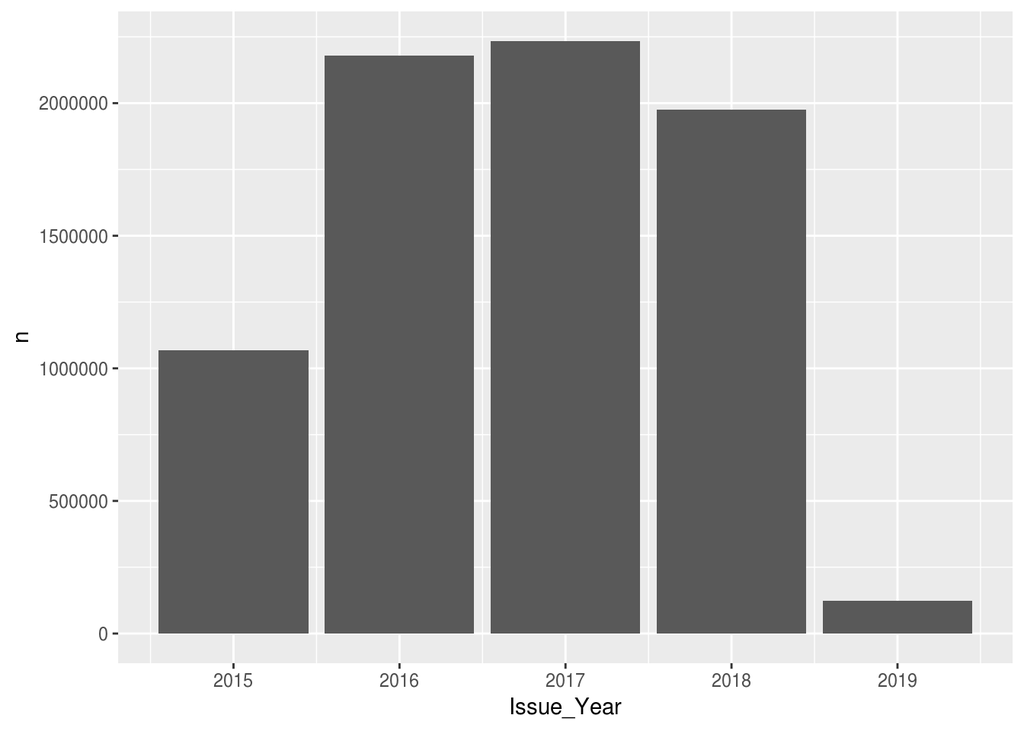

  ```r
  data %>%
    group_by(Issue_Year) %>%
    count() %>%
    collect() %>%
    ggplot() +
    geom_col(aes(x = Issue_Year, y = n))
  ```

- From the barchart and the table we can see that year `2017` has the most data.
2. When (which hour, weekday, month day, and month) are you most likely to get a ticket and when are you least likely to get a ticket?

   **Solution:**

   ```r
   # Hour
   data %>% group_by(Issue_Hour) %>%
     summarise(num = n()) %>%
     arrange(desc(num)) %>%
     collect() %>%
     slice(c(1, n()))
   ```

   ```
   ## # A tibble: 2 x 2
   ##   Issue_Hour    num
   ##        <int>  <int>
   ## 1         12 975063
   ## 2          5  53971
   ```

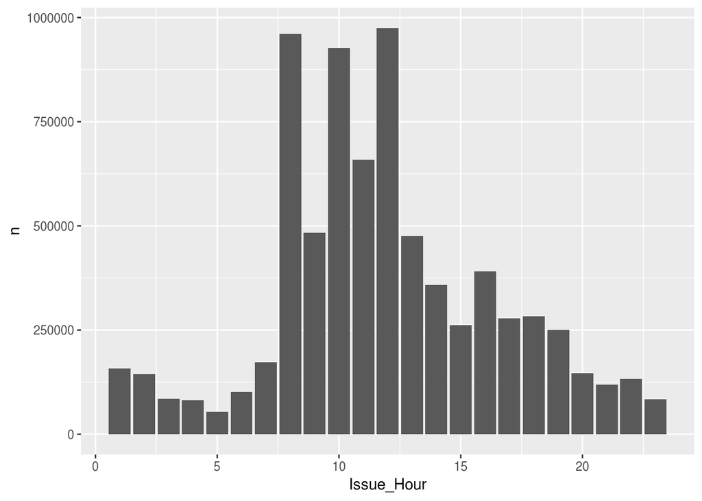

   ```r
   data %>%
     group_by(Issue_Hour) %>%
     count() %>%
     collect() %>%
     ggplot() +
     geom_col(aes(x = Issue_Hour, y = n))
   ```

- Based on the summary of count and barchart, it most likely to get a ticket at `12:00 PM` and least likely to get a ticket at `5:00 AM`.

  ```r
  # Weekday
  data %>% group_by(Issue_Wday) %>%
    summarise(num = n()) %>%
    arrange(desc(num)) %>%
    collect() %>%
    slice(c(1, n()))
  ```

  ```
  ## # A tibble: 2 x 2
  ##   Issue_Wday     num
  ##        <dbl>   <int>
  ## 1          3 1468900
  ## 2          1  369564
  ```

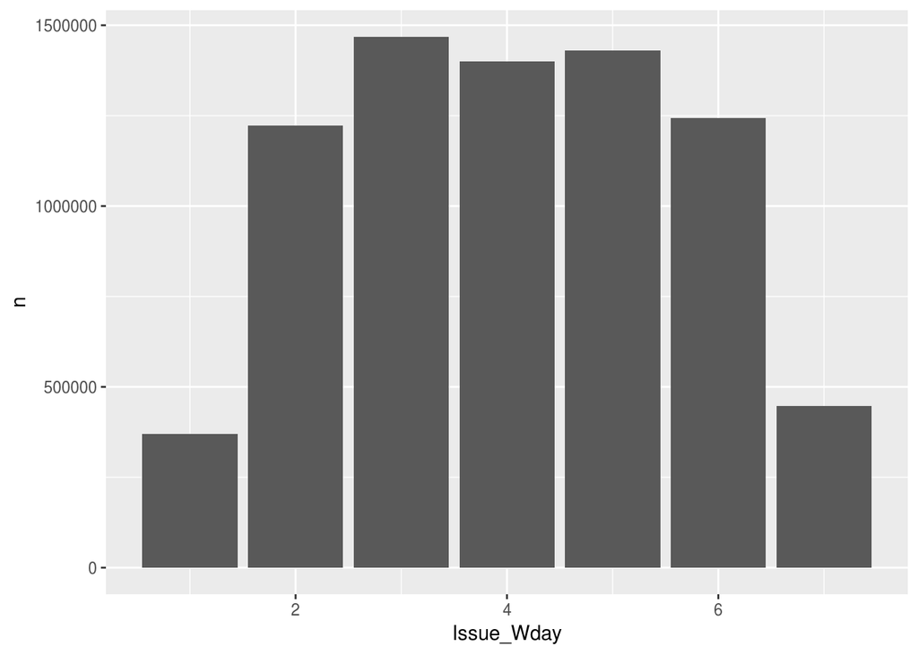

  ```r
  data %>%
    group_by(Issue_Wday) %>%
    count() %>%
    collect() %>%
    ggplot() +
    geom_col(aes(x = Issue_Wday, y = n))
  ```

  ```r
  # Month day
  data %>% group_by(Issue_Day) %>%
    summarise(num = n()) %>%
    arrange(desc(num)) %>%
    collect() %>%
    slice(c(1, n()))
  ```

  ```
  ## # A tibble: 2 x 2
  ##   Issue_Day    num
  ##       <int>  <int>
  ## 1        13 267419
  ## 2        31 157356
  ```

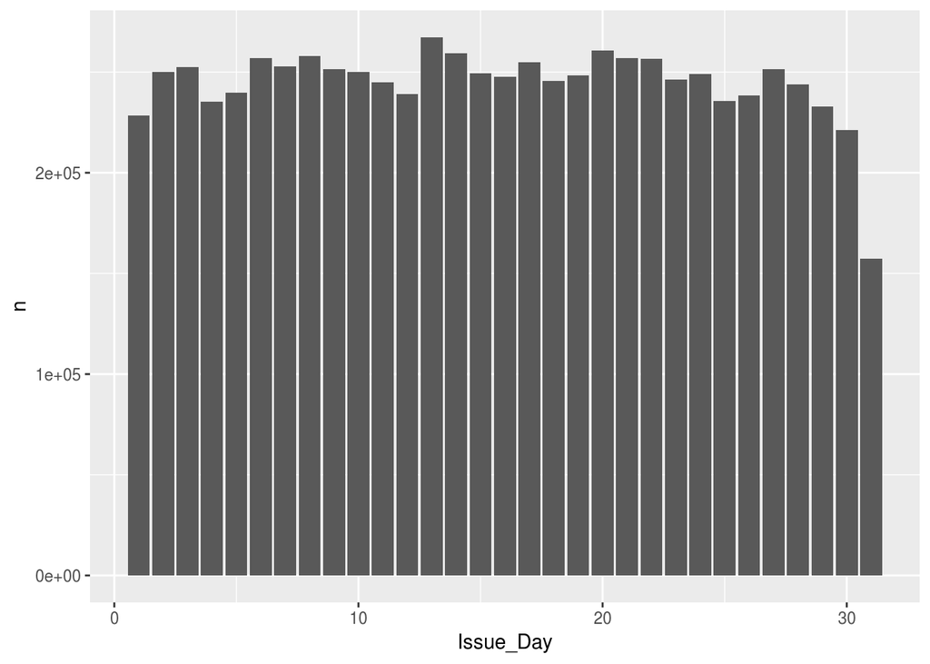

  ```r
  data %>%
    group_by(Issue_Day) %>%
    count() %>%
    collect() %>%
    ggplot() +
    geom_col(aes(x = Issue_Day, y = n))
  ```

- Based on the summary of count and barchart, it most likely to get a ticket at `13th` and least likely to get a ticket at `31st`.

  ```r
  # Month
  data %>% group_by(Issue_Month) %>%
    summarise(num = n()) %>%
    arrange(desc(num)) %>%
    collect() %>%
    slice(c(1, n()))
  ```

  ```
  ## # A tibble: 2 x 2
  ##   Issue_Month    num
  ##         <int>  <int>
  ## 1           8 752904
  ## 2           2 512428
  ```

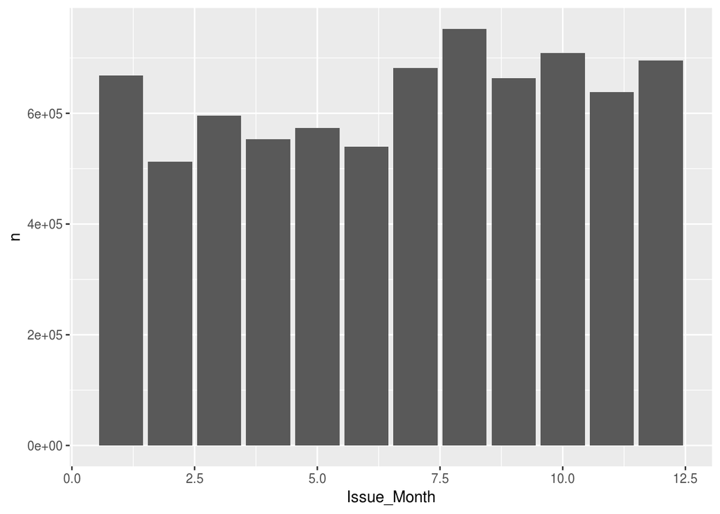

  ```r
  data %>%
    group_by(Issue_Month) %>%
    count() %>%
    collect() %>%
    ggplot() +
    geom_col(aes(x = Issue_Month, y = n))
  ```

- Based on the summary of count and barchart, it most likely to get a ticket at `August` and least likely to get a ticket at `February`.
3. Which car makes received most citations?

   **Solution:**

   ```r
   latix %>% filter(!is.na(Make)) %>%
     group_by(Make) %>%
     summarise(num = n()) %>%
     arrange(desc(num)) %>%
     head(1)
   ```

   ```
   ## # Source:     lazy query [?? x 2]
   ## # Database:   sqlite 3.22.0
   ## #   [/home/m280data/la_parking/LA_Parking_Citations.sqlite]
   ## # Ordered by: desc(num)
   ##   Make      num
   ##   <chr>   <int>
   ## 1 TOYT  1270804
   ```

- The `TOYOTA` received most citations.
4. How many different colors of cars were ticketed? Which color attracted most tickets?

   **Solution:**

   ```r
   colordata <- latix %>% filter(!is.na(Color)) %>%
     group_by(Color) %>%
     summarise(num = n()) %>%
     arrange(desc(num))

   colordata %>% summarise(num = n())
   ```

   ```
   ## # Source:   lazy query [?? x 1]
   ## # Database: sqlite 3.22.0
   ## #   [/home/m280data/la_parking/LA_Parking_Citations.sqlite]
   ##     num
   ##   <int>
   ## 1   103
   ```

   ```r
   colordata %>% head(1)
   ```

   ```
   ## # Source:     lazy query [?? x 2]
   ## # Database:   sqlite 3.22.0
   ## #   [/home/m280data/la_parking/LA_Parking_Citations.sqlite]
   ## # Ordered by: desc(num)
   ##   Color     num
   ##   <chr>   <int>
   ## 1 BK    1652621
   ```

- There are `103` different colors of cars were ticketed. The `Black` car attracted most tickets.
5. What are the most common ticket types?

   **Solution:**

   ```r
   latix %>% filter(!is.na(Violation_Description)) %>%
     group_by(Violation_Description) %>%
     summarise(num = n()) %>%
     arrange(desc(num)) %>%
     head(1)
   ```

   ```
   ## # Source:     lazy query [?? x 2]
   ## # Database:   sqlite 3.22.0
   ## #   [/home/m280data/la_parking/LA_Parking_Citations.sqlite]
   ## # Ordered by: desc(num)
   ##   Violation_Description     num
   ##   <chr>                   <int>
   ## 1 NO PARK/STREET CLEAN  2234699
   ```

- The most common ticket types is `NO PARK/STREET CLEAN`;
6. How much money was collected on parking tickets in 2016, 2017 and 2018?

   **Solution:**

   ```r
   latix %>%
     select(Issue_Year, Fine_amount) %>%
     filter(!is.na(Issue_Year), !is.na(Fine_amount)) %>%
     group_by(Issue_Year) %>%
     summarise(total = sum(Fine_amount, na.rm = TRUE)) %>%
     collect() %>% slice(c(2, 3, 4))
   ```

   ```
   ## # A tibble: 3 x 2
   ##   Issue_Year     total
   ##        <int>     <dbl>
   ## 1       2016 152145538
   ## 2       2017 157122489
   ## 3       2018 138875787
   ```

- Money collected on parking ticktets in 2016, 2017 and 2018 are `$152145538`, `$157122489`, `$138875787` respectively.
7. If you’ve been ticketed in LA County, did you find your ticket in this data set?

   **Solution:**I don’t have a car in LA county.
8. Read the blog http://www.brettrics.com/9-million-parking-tickets-la/ and try to reproduce plots using your data.